# *AlexNet - CNN Architecture*

## *Introduction*

*AlexNet was the winner of the 2012 Imagenet Large Scale Visual Recognition Challenge(ILSVRC-2012) submitted by Alex Krizhevsky, Ilya Sutskever, and. Geoffrey E. Hinton and this model beat its nearest contender by more than a 10% error rate. It was also after that year that more and deeper neural networks were proposed, such as the excellent vgg, GoogleLeNet. Its official data model has an accuracy rate of 57.1% and top 1-5 reaches 80.2%. This is already quite outstanding for traditional machine learning classification algorithms.*

*Before we proceed further let’s discuss the data present in the Imagenet dataset. It contains images from dogs, horses, cars, etc. It contains 1000 classes and each class contains thousands of images. So in total, there are approximately 1.2 million high-resolution images in this dataset used by researchers for training, testing, and validating the model designed by researchers.*

*[Paper - AlexNet](https://papers.nips.cc/paper/4824-imagenet-classification-with-deep-convolutional-neural-networks.pdf)*

## *Architecture*

*The AlexNet neural network architecture consists of 8 learned layers of which 5 are convolution layers, few are max-pooling layers, 3 are fully connected layers, and the output layer is a 1000 channel softmax layer. The pooling used here is Max pool.*

*Why 1000 channels of softmax layer are taken??* *This is because the Imagenet dataset contains 1000 different classes of images, so at the final output layer we have one node for each of these 1000 categories and the output layer is the softmax output layer.*

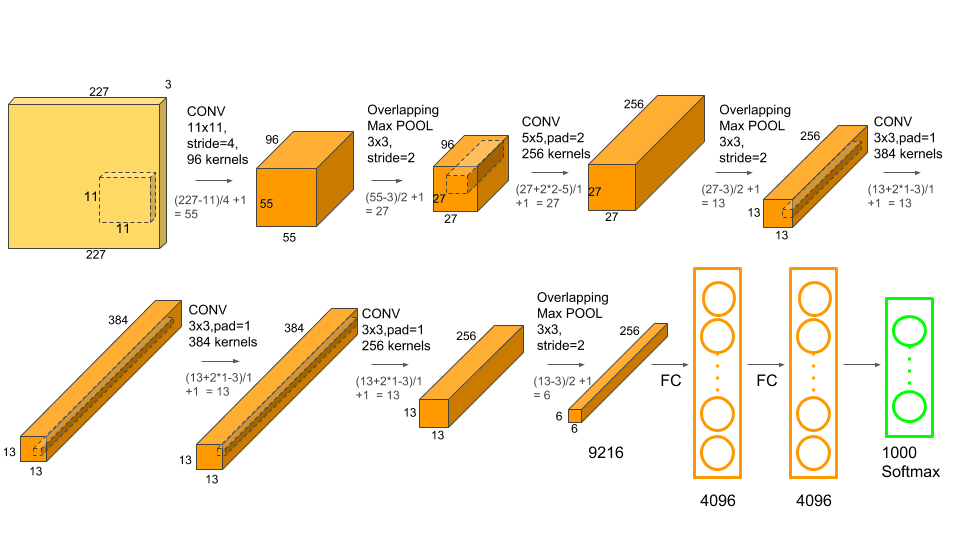

### *INPUT Layer*

*The input to the AlexNet network is a 227 x 227 size RGB image, so it’s having 3 different channels- red, green, and blue.*

### *C1 Layer - Convolution Layer*

*Then we have the First Convolution Layer in the AlexNet that has 96 different kernels with each kernel’s size of 11 x 11 and with stride equals 4. So the output of the first convolution layer gives you 96 different channels or feature maps because there are 96 different kernels and each feature map contains features of size 55 x 55.*

> *Size of Input*: N = 227 x 227

> *Size of Convolution Kernels*: f = 11 x 11

> *No. of Kernels*: 96

> *Strides*: S = 4

> *Padding*: P = 0

> *Size of each feature map = (227–11+0)/4+1 = 55*

*So every feature map after the first convolution layer is of the size 55 x 55.*

### *P1 Layer - Max Pooling Layer*

*After this convolution, we have an **Overlapping Max Pool Layer**, where the max-pooling is done over a window of 3 x 3, and stride equals 2. So, here we’ll find that as **our max pooling window is of size 3 x 3 but the stride is 2 that means max pooling will be done over an overlapped window**. After this pooling, the size of the feature map is reduced to 27 x 27 and the number of feature channels remains 96.*

> *Size of Input*: N = 55 x 55

> *Size of Convolution Kernels*: f = 3 x 3

> *Strides*: S = 2

> *Padding*: P = 0

> *Size of each feature map* = (55–3+0)/2+1 = 27

*So every feature map after this pooling is of the size 27 x 27.*

### *C2 Layer - Convolution Layer*

*Then we have Second Convolution Layer where kernel size is 5 x 5 and in this case, we use the padding of 2 so that the output of the convolution layer remains the same as the input feature size. Thus, the size of feature maps generated by this second convolution layer is 27 x 27 and the number of kernels used in this case is 256 so that means from this convolution layer output we’ll get 256 different channels or feature maps and every feature map will be of size 27 x 27.*

> *Size of Input*: N = 27 x 27

> *Size of Convolution Kernels*: f = 5 x 5

> *No. of Kernels*: 256

> *Strides*: S = 1

> *Padding*: P = 2

> *Size of each feature map* = (27–5+4)/1+1 = 27

*So every feature map after the second convolution layer is of the size 27 x 27.*

### *P2 Layer - Max Pooling Layer*

*Now again we have an Overlapping Max Pool Layer, where the max-pooling is again done over a window of 3 x 3, and stride equals 2 which means max-pooling is done over overlapping windows and output of this become 13 x 13 feature maps and number of channels we get is 256.*

> *Size of Input*: N = 27 x 27

> *Size of Convolution Kernels*: f = 3 x 3

> *Strides*: S = 2

> *Padding*: P = 0

> *Size of each feature map* = (27–3+0)/2+1 = 13

*So every feature map after this pooling is of the size 13 x13.*

### *C3 Layer - Convolution Layer*

*Then we have Three Consecutive Convolution Layers of which the first convolution layer is having the kernel size of 3 x 3 with padding equal to 1 and 384 kernels give you 384 feature maps of size 13 x 13 which passes through the next convolution layer.*

> *Size of Input*: N = 13 x 13

> *Size of Convolution Kernels*: f = 3 x 3

> *No. of Kernels*: 384

> *Strides*: S = 1

> *Padding*: P = 1

> *Size of each feature map* = (13–3+2)/1+1 = 13

### *C4 Layer - Convolution Layer*

> *Size of Input*: N = 13 x 13

> *Size of Convolution Kernels*: f = 3 x 3

> *No. of Kernels*: 384

> *Strides*: S = 1

> *Padding*: P = 1

> *Size of each feature map* = (13–3+2)/1+1 = 13

### *C5 Layer - Convolution Layer*

*The output of this second convolution is again passed through a convolution layer where kernel size is again 3 x 3 and padding equal to 1 which means the output of this convolution layer generates feature maps of the same size of 13 x 13. But in this case, AlexNet uses 256 kernels so that means at the input of this convolution we have 384 channels which now get converted to 256 channels or we can say 256 feature maps are generated at the end of this convolution and every feature map is of size 13 x 13.*

> *Size of Input*: N = 13 x 13

> *Size of Convolution Kernels*: f = 3 x 3

> *No. of Kernels*: 256

> *Strides*: S = 1

> *Padding*: P = 1

> *Size of each feature map* = (13–3+2)/1+1 = 13

### *P3 Layer - Max Pooling Layer*

*Followed by the above is the next Overlapping Max Pool Layer, where the max-pooling is again done over a window of 3 x 3 and stride equal to 2 and that gives you the output feature maps and the number of channels remains same as 256 and the size of each feature map is 6 x 6.*

> *Size of Input*: N = 13 x 13

> *Size of Convolution Kernels*: f = 3 x 3

> *Strides*: S = 2

> *Padding*: P = 0

> *Size of each feature map* = (13–3+0)/2+1 = 6

### *Fully Connected Layers*

*Now we have a fully connected layer which is the same as a multi-layer perception. The first two fully-connected layers have 4096 nodes each. After the above mentioned last max-pooling, we have a total of 6 *6* 256 i.e. 9216 nodes or features and each of these nodes is connected to each of the nodes in this fully-connected layer. So the number of connections we’ll have in this case is 9216 *4096. And then every node from this fully connected convolution layer provides input to every node in the second fully connected layer. So here we’ll have a total of 4096* 4096 connections as in the second fully connected layer also we have 4096 nodes.*

*And then, in the end, we have an output layer with 1000 softmax channels. Thus the number of connections between the second fully connected layer and the output layer is 4096 * 1000.*

## *Complete Architecture Recap*

| Size / Operation | Filter | Depth | Stride | Padding | Number of Parameters | Forward Computation |
| --- | --- | --- | --- | --- | --- | --- |
| 3* 227 * 227 |  |  |  |  |  |  |
| Conv1 + Relu | 11 * 11 | 96 | 4 |  | (11*11*3 + 1) * 96=34944 | (11*11*3 + 1) * 96 * 55 * 55=105705600 |
| 96 * 55 * 55 |  |  |  |  |  |  |
| Max Pooling | 3 * 3 |  | 2 |  |  |  |
| 96 * 27 * 27 |  |  |  |  |  |  |
| Norm |  |  |  |  |  |  |
| Conv2 + Relu | 5 * 5 | 256 | 1 | 2 | (5 * 5 * 96 + 1) * 256=614656 | (5 * 5 * 96 + 1) * 256 * 27 * 27=448084224 |
| 256 * 27 * 27 |  |  |  |  |  |  |
| Max Pooling | 3 * 3 |  | 2 |  |  |  |
| 256 * 13 * 13 |  |  |  |  |  |  |
| Norm |  |  |  |  |  |  |
| Conv3 + Relu | 3 * 3 | 384 | 1 | 1 | (3 * 3 * 256 + 1) * 384=885120 | (3 * 3 * 256 + 1) * 384 * 13 * 13=149585280 |
| 384 * 13 * 13 |  |  |  |  |  |  |
| Conv4 + Relu | 3 * 3 | 384 | 1 | 1 | (3 * 3 * 384 + 1) * 384=1327488 | (3 * 3 * 384 + 1) * 384 * 13 * 13=224345472 |
| 384 * 13 * 13 |  |  |  |  |  |  |
| Conv5 + Relu | 3 * 3 | 256 | 1 | 1 | (3 * 3 * 384 + 1) * 256=884992 | (3 * 3 * 384 + 1) * 256 * 13 * 13=149563648 |
| 256 * 13 * 13 |  |  |  |  |  |  |
| Max Pooling | 3 * 3 |  | 2 |  |  |  |
| 256 * 6 * 6 |  |  |  |  |  |  |
| Dropout (rate 0.5) |  |  |  |  |  |  |
| FC6 + Relu |  |  |  |  | 256 * 6 * 6 * 4096=37748736 | 256 * 6 * 6 * 4096=37748736 |
| 4096 |  |  |  |  |  |  |
| Dropout (rate 0.5) |  |  |  |  |  |  |
| FC7 + Relu |  |  |  |  | 4096 * 4096=16777216 | 4096 * 4096=16777216 |
| 4096 |  |  |  |  |  |  |
| FC8 + Relu |  |  |  |  | 4096 * 1000=4096000 | 4096 * 1000=4096000 |
| 1000 classes |  |  |  |  |  |  |
| Overall |  |  |  |  | 62369152=62.3 million | 1135906176=1.1 billion |
| Conv VS FC |  |  |  |  | Conv:3.7million (6%) , FC: 58.6 million (94% ) | Conv: 1.08 billion (95%) , FC: 58.6 million (5%) |

## *Training on multiple GPUs*

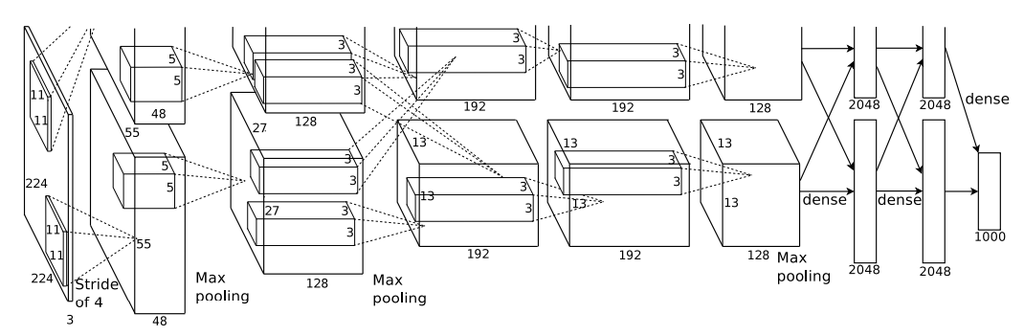

*As we can see from the figure that inter-**AlexNet was implemented in two channels** because **1.2 million training examples** were too big to fit on one GPU. So half of the network is put in one channel and the other half of the network is put into another channel. And as they are into two different channels so that made it possible to train this network on two different GPU cards. The GPU used was **GTX 580 3GB GPUs** and the network took between five to six days to get trained. Here **cross-GPU parallelization (i.e. One GPU communicating with other GPU) is happening** at some places like kernels of layer 3 take input from all kernel maps in layer 2. However, kernels in layer 4 take input only from those kernel maps in layer 3 which stay on the same GPU.*

## *How does AlexNet achieve better results?*

### *ReLU as an Activation Function*

- *Vanishing Gradient Problem*

*If we use the non -linear activation function like sigmoidal or tan hyperbolic (tanh) function then it gives a risk of vanishing gradient that is in some cases when we are training the network with the gradient descent procedure vanishing gradient means that the gradient of the error function may become too small such that using that gradient when you try to update the network parameters, the update becomes almost negligible because the gradient itself is very small, that is what is vanishing gradient problem.*

- *Why does the Vanishing Gradient Problem arise??*

*As we know with the graph of sigmoid function that if the value of an input is very high then it saturates to 1 and if the value of an input is too low then it saturates to 0. So when we try to take the gradient at these points the gradient is almost 0. The same thing is true if our non-linear activation function is tanh.*

- *How to prevent Vanishing Gradient Problem??*

*To prevent the vanishing gradient problem we use the **relu (Rectified Linear Unit) activation function**. As relu function is **max(x, 0) so for x>0** the **gradient is always constant** so this is the advantage when we use relu as the non-linear activation function.*

- *ReLU has Faster Training Rate*

- *Problem using ReLU as an Activation Function*

### *Local Response Normalization*

*Local Response Normalization can be done across the channel and also it can be done within a channel. When we do this normalization across the channel then it is known as **Inter-channel normalization** and when the normalization occurs between the features of the same channel it is known as **Intra-channel normalization**. Inter-channel normalization was performed in the AlexNet network. Based on the neighborhood two types of LRN can be seen from the below figure:*

[figure not shown]

*Inter-Channel Normalization* *: Here normalization is performed across the channels and hence here neighborhood is the depth of the channel. The normalization output at the position (x,y) is given by the following formula:*

[figure not shown]

*Here, b[i, (x,y)] is the output at the location (x,y) in the ith channel and a[i, (x,y)] is the original value at location (x,y) in the ith channel. So in this, we normalize a[i, (x,y)] by a factor, and that factor is given by k plus alpha times sum of a[j, (x,y)] where this j varies between the neighboring channels. Thus j varies between a maximum of (0 and i-n/2) and a minimum of (N-1 and i+n/2) that means n/2 number of channels before and n/2 number of channels after i. 0 and N-1 are put to take care of the first and last channels. After this normalization, the output will be bounded and it can be shown with the subsequent figure.*

[figure not shown]

*Intra-channel Normalization* *: Here normalization occurs between the neighboring neurons across the surface of the same channel.*

[figure not shown]

*Here, b[k, (x,y)] is the output at the location (x,y) in the kth channel and a[k, (x,y)] is the original value at location (x,y) in the kth channel. So in this, we normalize a[k, (x,y)] by a factor, and that factor is given by k plus alpha times summation of the sum of squares of feature values within the neighborhood of x and y. Min and Max are put to take care of the features which are at the boundary of the feature maps. After this normalization, the output will be bounded and it can be shown with the subsequent figure.*

[figure not shown]

### *Problem of Overfitting*

*As there are **60 million parameters to be trained**, so this would lead to the problem of overfitting which means the network would be able to learn or memorize the training data very properly but in case of testing input, it won’t be able to code the properties or features of the input data. So in such a case, the performance of the model in case of training may not be acceptable. So to reduce this overfitting issue additional augmented data was generated from the existing data and the **augmentation**(i.e. generation of new images from the original images by making variations like horizontal flipping, vertical flipping, zooming, etc. in the original images ) was done by mirroring and bt taking random crops from the input data. Another method by which the problem of overfitting was taken care of is by using **dropout regularization**.*

#### *Dropout Regularization*

*In this randomly selected neuron or randomly selected nodes, which are selected with a probability of 0.5 are dropped from the network temporarily. So the probability of the nodes that are removed and the probability of the nodes that are retained both will be equal to 0.5. So the dropout means that the node which has been dropped out will not pass its output to the subsequent nodes in the subsequent layers downstream and for the same nodes during backward propagation, no updation will take place as removing the nodes will also remove its subsequent connections as well. But this would increase the number of iterations required for training the model but this would make the model less vulnerable to overfitting thus, generalizing the model.*

[figure not shown]

## *Summary*

*Architecture*

- *5 Convolutional layers.*
- *3 Fully connected layers.*
- *3 Overlapping Max pooling layers.*
- *ReLU as activation function for hidden layer.*
  - *Avoid vanishing gradients for positive values.*
  - *More computationally efficient to compute than sigmoid and tanh.*
  - *Better convergence performance than sigmoid and tanh.*
- *Softmax as activation function for output layer.*
- *60,000,000 trainable parameters.*
- *Cross-entropy as cost function*
- *Mini-batch gradient descent with Momentum optimizer.*
  - *Batch size : 128.*
  - *Momentum = 0.9.*
  - *Weight decay = 0.0005.*
  - *Learning rate: 0.01. Equal learning rate for all layers and diving by 10 when validation error stopped improving.*
- *Local Response Normalization*
  - *it helps with generalization.*

*AlexNet Training Details*

- *Trained with ILSVRC-2012 dataset (1.2 million training images, 50,000 validation images, and 150,000 testing images.).*
- *Trained on 90 epochs.*
- *Weight initialization* *: zero-mean Gaussian distribution and a standard deviation of 0.01.*
- *Bias initialization* *: 1 for 2nd/4th/5th conv layers and all fully-connected layers and 0 for remaining layers.*

*AlexNet Inputs*

*RGB image of size 256 x 256. If not, training/test set images need to be resized.*

_Example: image*size = 1024 x 500 => Smaller dimension is resized to 256 and resulting image is cropped to obtain a 256 x 256 image. The RGB image of size 256 x 256 will then be cropped into 227 x 227 (cf Data Augmentation part). The paper mistakenly says 224 x 224.*

*AlexNet Overfit Prevention*

- *Dropout.*
  - *50% dropout rate.*
- *Data Augmentation.*
  - *Translations and horizontal reflections (mirroring): Extract random 227 x 227 crops from 256 x 256 images.*
  - *Translation on 1 image: (256−227)∗(256−227) = 841 possible images.*
  - *Mirroring : x2 the training set size.*
  - *New training set size = 1.2 millions 2 841 = 1.2 millions * 1682 images.*
  - *Altering the intensities of RGB channels: performing PCA on the set of RGB pixel values throughout the ImageNet training set. Doing this approximately captures an important property of natural images: object identity is invariant to changes in the intensity and color of the illumination.*

## *Code Implementation*

```python
#Importing library

import keras
from keras.models import Sequential
from keras.layers import Dense, Activation, Dropout, Flatten, Conv2D, MaxPooling2D
from keras.layers.normalization import BatchNormalization
import numpy as np

np.random.seed(1000)
```

```python
#Keras library for CIFAR dataset

from keras.datasets import cifar10
(x_train, y_train),(x_test, y_test)=cifar10.load_data()

#Train-validation-test split
from sklearn.model_selection import train_test_split
x_train,x_val,y_train,y_val=train_test_split(x_train,y_train,test_size=.3)

#Dimension of the CIFAR10 dataset
print((x_train.shape,y_train.shape))
print((x_val.shape,y_val.shape))
print((x_test.shape,y_test.shape))
```

```
((35000, 32, 32, 3), (35000, 1))
((15000, 32, 32, 3), (15000, 1))
((10000, 32, 32, 3), (10000, 1))
```

```python
# Onehot Encoding the labels
from keras.utils import to_categorical

#Since we have 10 classes we should expect the shape[1] of y_train,y_val and y_test to change from 1 to 10
y_train=to_categorical(y_train)
y_val=to_categorical(y_val)
y_test=to_categorical(y_test)

#Verifying the dimension after one hot encoding
print((x_train.shape,y_train.shape))
print((x_val.shape,y_val.shape))
print((x_test.shape,y_test.shape))
```

```
((35000, 32, 32, 3), (35000, 10))
((15000, 32, 32, 3), (15000, 10))
((10000, 32, 32, 3), (10000, 10))
```

```python
#Image Data Augmentation
from keras.preprocessing.image import ImageDataGenerator

train_generator = ImageDataGenerator(rotation_range=2,
                                     horizontal_flip=True,
                                     zoom_range=.1 )

val_generator = ImageDataGenerator(rotation_range=2,
                                   horizontal_flip=True,
                                   zoom_range=.1)

test_generator = ImageDataGenerator(rotation_range=2,
                                    horizontal_flip= True,
                                    zoom_range=.1)

#Fitting the augmentation defined above to the data
train_generator.fit(x_train)
val_generator.fit(x_val)
test_generator.fit(x_test)
```

```python
#Instantiation
AlexNet = Sequential()

#1st Convolutional Layer
AlexNet.add(Conv2D(filters=96, input_shape=(32,32,3), kernel_size=(11,11), strides=(4,4), padding='same'))
AlexNet.add(BatchNormalization())
AlexNet.add(Activation('relu'))
AlexNet.add(MaxPooling2D(pool_size=(2,2), strides=(2,2), padding='same'))

#2nd Convolutional Layer
AlexNet.add(Conv2D(filters=256, kernel_size=(5, 5), strides=(1,1), padding='same'))
AlexNet.add(BatchNormalization())
AlexNet.add(Activation('relu'))
AlexNet.add(MaxPooling2D(pool_size=(2,2), strides=(2,2), padding='same'))

#3rd Convolutional Layer
AlexNet.add(Conv2D(filters=384, kernel_size=(3,3), strides=(1,1), padding='same'))
AlexNet.add(BatchNormalization())
AlexNet.add(Activation('relu'))

#4th Convolutional Layer
AlexNet.add(Conv2D(filters=384, kernel_size=(3,3), strides=(1,1), padding='same'))
AlexNet.add(BatchNormalization())
AlexNet.add(Activation('relu'))

#5th Convolutional Layer
AlexNet.add(Conv2D(filters=256, kernel_size=(3,3), strides=(1,1), padding='same'))
AlexNet.add(BatchNormalization())
AlexNet.add(Activation('relu'))
AlexNet.add(MaxPooling2D(pool_size=(2,2), strides=(2,2), padding='same'))

#Passing it to a Fully Connected layer
AlexNet.add(Flatten())
# 1st Fully Connected Layer
AlexNet.add(Dense(4096, input_shape=(32,32,3,)))
AlexNet.add(BatchNormalization())
AlexNet.add(Activation('relu'))
# Add Dropout to prevent overfitting
AlexNet.add(Dropout(0.4))

#2nd Fully Connected Layer
AlexNet.add(Dense(4096))
AlexNet.add(BatchNormalization())
AlexNet.add(Activation('relu'))
#Add Dropout
AlexNet.add(Dropout(0.4))

#3rd Fully Connected Layer
AlexNet.add(Dense(1000))
AlexNet.add(BatchNormalization())
AlexNet.add(Activation('relu'))
#Add Dropout
AlexNet.add(Dropout(0.4))

#Output Layer
AlexNet.add(Dense(10))
AlexNet.add(BatchNormalization())
AlexNet.add(Activation('softmax'))

#Model Summary
AlexNet.summary()
```

```
Model: "sequential"
_________________________________________________________________
Layer (type)                 Output Shape              Param #
=================================================================
conv2d (Conv2D)              (None, 8, 8, 96)          34944
_________________________________________________________________
batch_normalization (BatchNo (None, 8, 8, 96)          384
_________________________________________________________________
activation (Activation)      (None, 8, 8, 96)          0
_________________________________________________________________
max_pooling2d (MaxPooling2D) (None, 4, 4, 96)          0
_________________________________________________________________
conv2d_1 (Conv2D)            (None, 4, 4, 256)         614656
_________________________________________________________________
batch_normalization_1 (Batch (None, 4, 4, 256)         1024
_________________________________________________________________
activation_1 (Activation)    (None, 4, 4, 256)         0
_________________________________________________________________
max_pooling2d_1 (MaxPooling2 (None, 2, 2, 256)         0
_________________________________________________________________
conv2d_2 (Conv2D)            (None, 2, 2, 384)         885120
_________________________________________________________________
batch_normalization_2 (Batch (None, 2, 2, 384)         1536
_________________________________________________________________
activation_2 (Activation)    (None, 2, 2, 384)         0
_________________________________________________________________
conv2d_3 (Conv2D)            (None, 2, 2, 384)         1327488
_________________________________________________________________
batch_normalization_3 (Batch (None, 2, 2, 384)         1536
_________________________________________________________________
activation_3 (Activation)    (None, 2, 2, 384)         0
_________________________________________________________________
conv2d_4 (Conv2D)            (None, 2, 2, 256)         884992
_________________________________________________________________
batch_normalization_4 (Batch (None, 2, 2, 256)         1024
_________________________________________________________________
activation_4 (Activation)    (None, 2, 2, 256)         0
_________________________________________________________________
max_pooling2d_2 (MaxPooling2 (None, 1, 1, 256)         0
_________________________________________________________________
```

[output cut: 21 more lines]

```
_________________________________________________________________
activation_7 (Activation)    (None, 1000)              0
_________________________________________________________________
dropout_2 (Dropout)          (None, 1000)              0
_________________________________________________________________
dense_3 (Dense)              (None, 10)                10010
_________________________________________________________________
batch_normalization_8 (Batch (None, 10)                40
_________________________________________________________________
activation_8 (Activation)    (None, 10)                0
=================================================================
Total params: 25,730,506
Trainable params: 25,709,350
Non-trainable params: 21,156
_________________________________________________________________
```

```python
# Compiling the model
AlexNet.compile(loss = keras.losses.categorical_crossentropy, optimizer= 'adam', metrics=['accuracy'])
```

```python
#Defining the parameters
batch_size = 100
epochs = 100

#Training the model
AlexNet.fit_generator(train_generator.flow(x_train, y_train, batch_size=batch_size),
                      epochs = epochs,
                      steps_per_epoch = x_train.shape[0]//batch_size,
                      validation_data = val_generator.flow(x_val, y_val, batch_size=batch_size),
                      verbose=1)
```

```
WARNING:tensorflow:From <ipython-input-7-508a7b400870>:10: Model.fit_generator (from tensorflow.python.keras.engine.training) is deprecated and will be removed in a future version.
Instructions for updating:
Please use Model.fit, which supports generators.
```

```
<tensorflow.python.keras.callbacks.History at 0x7fc03b148cc0>
```

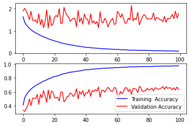

```python
# After successful training, we will visualize its performance.

import matplotlib.pyplot as plt
# Plotting the training and validation loss

f,ax=plt.subplots(2,1) #Creates 2 subplots under 1 column

# Assigning the first subplot to graph training loss and validation loss
ax[0].plot(AlexNet.history.history['loss'],color='b',label='Training Loss')
ax[0].plot(AlexNet.history.history['val_loss'],color='r',label='Validation Loss')

# Plotting the training accuracy and validation accuracy
ax[1].plot(AlexNet.history.history['accuracy'],color='b',label='Training  Accuracy')
ax[1].plot(AlexNet.history.history['val_accuracy'],color='r',label='Validation Accuracy')

plt.legend()
```

```python
# Making prediction

y_pred = AlexNet.predict_classes(x_test)
y_true = np.argmax(y_test,axis=1)
```

[output not shown]

```python
y_pred
```

```
array([3, 1, 9, ..., 5, 1, 7])
```

```python
y_true
```

```
array([3, 8, 8, ..., 5, 1, 7])
```

```python
# Plotting the confusion matrix
from sklearn.metrics import confusion_matrix

confusion_mtx = confusion_matrix(y_true,y_pred)

class_names=['airplane', 'automobile', 'bird', 'cat', 'deer', 'dog', 'frog', 'horse', 'ship', 'truck']
```

```python
confusion_mtx
```

```
array([[903,   7,  16,   8,   5,   1,   1,   3,  14,  42],
       [ 84, 649,   3,  14,   0,   3,   6,   2,   8, 231],
       [195,   6, 481, 123,  33,  50,  33,  28,   4,  47],
       [129,   6,  36, 586,  21, 106,  18,  28,   7,  63],
       [151,   1,  64, 146, 414,  55,  39,  89,   4,  37],
       [ 76,   2,  29, 283,  14, 472,  20,  70,   3,  31],
       [ 68,   6,  20, 147,  20,  34, 651,  10,   1,  43],
       [101,   0,  10,  55,  10,  41,   3, 702,   1,  77],
       [243,  22,  13,  18,   3,   3,   1,   1, 601,  95],
       [ 78,  38,   3,  10,   0,   2,   0,   3,   7, 859]])
```

```python
# Classification accuracy
from sklearn.metrics import accuracy_score

acc_score = accuracy_score(y_true, y_pred)
print('Accuracy Score = ', acc_score)
```

```
Accuracy Score =  0.6318
```

*Another Example: [Multi-Class Image Classification using Alexnet Deep Learning Network implemented in Keras API](https://medium.com/analytics-vidhya/multi-class-image-classification-using-alexnet-deep-learning-network-implemented-in-keras-api-c9ae7bc4c05f)*